# Quiz #2

Bri Bentley

Last knit on January 30, 2018 at 08:48:10 PM

**Directions: Change the author field in the `YAML` from “Your Name” to your name using the convention of FirstName LastName. For example, my entry would be `author: "Alan Arnholt"`. The data frame `ncbirths` contains the variables `fage`, `mage`, `mature`, `weeks`, `premie`, `visits`, `marital`, `gained`, `weight`, `lowbirthweight`, `gender`, `habit`, and `whitemom`. Store this file as `Quiz02.Rmd` inside your `Quizzes` directory. When you finish, commit your changes and push your work to GitHub. Use the commit message `Finished Quiz 02!`. Verify you can see your files at `https://github.com/STAT-ATA-ASU/YourLast-YourFirst-STT5812-SP18/tree/master/Quizzes`.**

```r
library(openintro)
names(ncbirths)
```

```
 [1] "fage"           "mage"           "mature"         "weeks"
 [5] "premie"         "visits"         "marital"        "gained"
 [9] "weight"         "lowbirthweight" "gender"         "habit"
[13] "whitemom"
```

```r
# Type ?ncbirths
# in the console to open the help file
```

1. Compute mean, standard deviation, and number of non-missing observations for the weight gained during pregnancy (`gained`) by mothers according to their level of `mature` (`mature mom` or `younger mom`).

```r
library(dplyr)
ncbirths %>%
  group_by(mature)%>%
  summarize(Means = mean(gained, na.rm = TRUE), SD = sd(gained, na.rm = TRUE), n = n())
```

```
# A tibble: 2 x 4
  mature      Means    SD     n
  <fct>       <dbl> <dbl> <int>
1 mature mom   28.8  13.5   133
2 younger mom  30.6  14.3   867
```

2. Based on your answers to question 1, the density plots shown in Figure 1, and the Q-Q plots shown in Figure 2
   - Should you pool or not pool the variances to compute a confidence interval for the mean weight gained during pregnancy for mature moms minus the mean weight gained during pregnancy for younger mothers $\left( \mu_{\text{mature mom}} - \mu_{\text{younger mom}} \right)$?
   - Construct a 90% confidence interval for the mean weight gained during pregnancy for mature moms minus the mean weight gained during pregnancy for younger mothers $\left( \mu_{\text{mature mom}} - \mu_{\text{younger mom}} \right)$.
   - Does your confidence interval contain zero? If so, what does this mean?

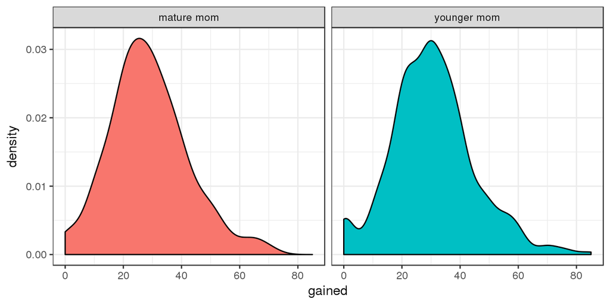

Figure 1: Density plots of weight gained (lbs.)

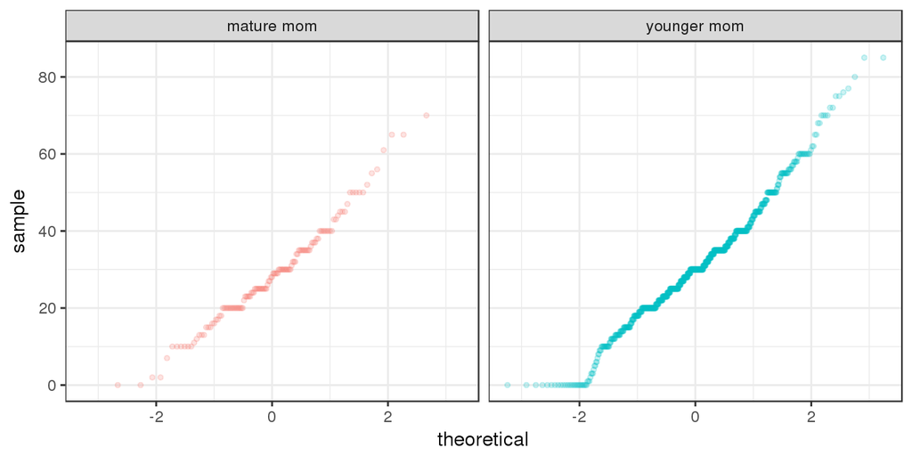

Figure 2: Q-Q plot of weight gained by `mature`

```r
CI <- t.test(gained ~ mature, data = ncbirths, conf.level = 0.90)$conf
CI
```

```
[1] -3.8957318  0.3562741
attr(,"conf.level")
[1] 0.9
```

```r
library(binom)
xtabs(~mature, data = ncbirths)
```

```
mature
 mature mom younger mom
        133         867
```

```r
binom.confint(x = 133, n = (133 + 867), methods = "wilson")
```

```
  method   x    n  mean     lower     upper
1 wilson 133 1000 0.133 0.1133512 0.1554577
```

The 95% Wilson confidence interval for the proportion of mature mothers in North Carolina is $CI_{0.95}(\pi) = [0.1133512, 0.1554577]$.

4. Compute a 90% confidence interval for the variance in weight gained during pregnancy by North Carolina mature mothers.

```r
# Your code here
# 90% CI for sigma^2

LCL <- ((133+867-1)*(13.48244)^2)/(qchisq(.05,133+867-1))

UCL <- ((133+867-1)*(13.48244)^2)/(qchisq(.95,133+867-1))

LCL
```

```
[1] 195.9727
```

```r
UCL
```

```
[1] 169.1386
```